# Territórios relacionais

Hernany Castro | Vira e Mexe

setembro/2024

# Acesse a apresentação

[figure not shown]

# Introdução

- A proposta é discutir territórios relacionais em Maringá/PR, a partir de dados do CadÚnico
- Nosso problema é como usar o CadÚnico para mapear padrões territorializados de condições de vida e de vínculos sociais que permitam o desenvolvimento de estratégias coletivizadas de proteção social?
- O objetivo é discutir metodologias que permitam mapear padrões territorializados de reprodução de situações de desproteção social, a partir da identificação de convergências entre condições de vida e laços sociais nos dados do cadastro único
- Apresenta-se técnicas de análise estatística combinadas com técnicas etnográficas adotadas em pesquisas sobre a situação de rua, além de exercícios analíticos sobre os dados do cadastro único e da folha de pagamento de benefícios eventuais

# 1. Notas sobre a noção Território relacional

- Territórios são espaços relacionais que reúnem vivências e práticas sociais cotidianas, são formas de solidariedade enquanto elementos e elos de forças sociais, como formas de vivências particulares em busca de proteção e segurança social
- As vivências territoriais permitem captar as dinâmicas e os nexos das relações socio-históricas na cidade, as quais mediatizam tempo e espaço, economia e cultura
- Território é monitorado reflexivamente
- Os descompassos e as sobreposições de tempo e espaço no território desencadeiam uma economia da ação
- O exercício de deciframento do território envolve, por um lado, o deciframento de indicadores, números, dispositivos legais e institucionais, como, por outro lado, miríades relacionais do tete a tete, o cotidiano vivido
- A dualidade entre territórios de vida e territórios de vivência expressa a contraposição de forças históricas que se desdobram em formas de sociação na cidade moderna

# 2. Implicações metodológicas

- Que método utilizamos atualmente para identificar territórios?
- Porquê métodos mistos?
- É possível combinar Estatística e Etnografia para identificar territórios?

# 3. Três exemplos: AFC, AI e PCA

### 3.1 Análise Fatorial por Correspondência - AFC

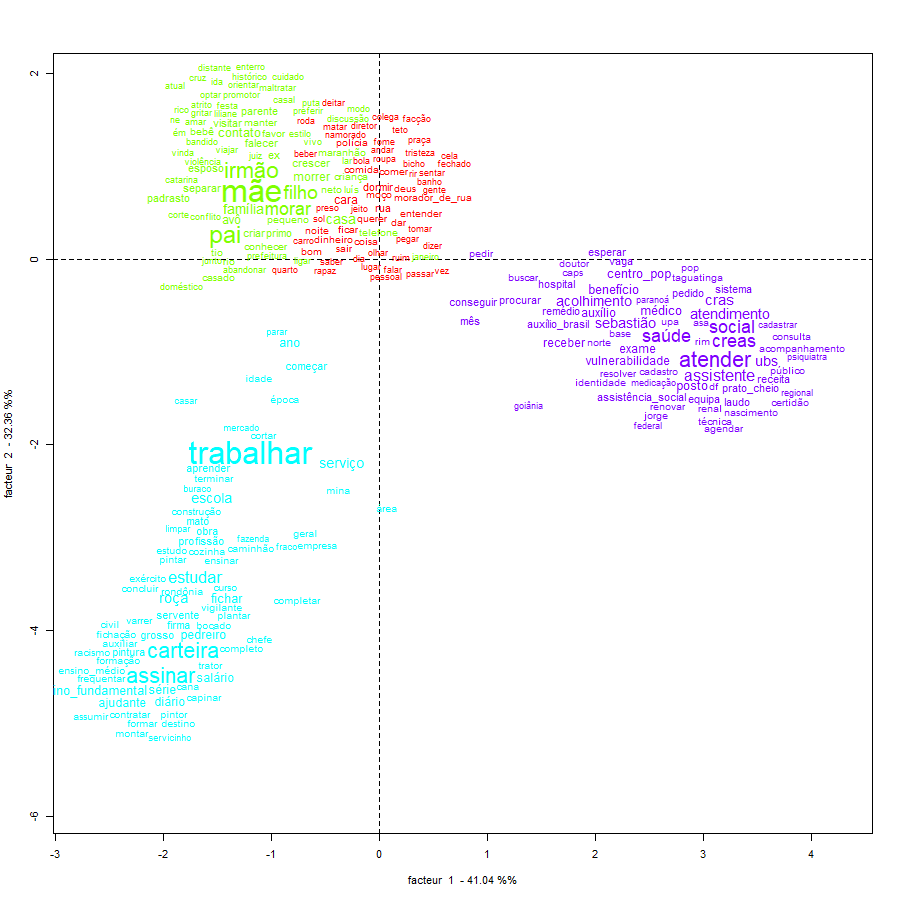

### 3.2 Inteligência Artificial - AI

Martins, L. F; Souza, F. R.; Freitas, J. M. (2024). requalify.ai (Version 0.1)[online software]. https://requalify.ai

O requalify.ai é um software inteligência artificial (IA) que utiliza Large Language Models (LLMs) com arquitetura Generative Pre-trained Transformer (GPT) para apoiar a análise de dados qualitativos. Ele adota uma combinação de técnicas avançadas de processamento de linguagem natural (PLN) em uma plataforma interativa que permite analisar dados qualitativos utilizando técnicas clássicas e apoiadas por IA.

Resumo

O texto aborda a problemática das invasões de áreas públicas por moradores de rua em diferentes regiões de Brasília, destacando problemas como sujeira, uso de drogas, insegurança, ameaças e brigas. Há solicitações de intervenção do poder público para solucionar esses problemas, incluindo a retirada das famílias em situação de rua, ações de fiscalização e busca por soluções de inclusão social. A falta de ações efetivas por parte do governo é ressaltada, assim como a preocupação com a formação de futuras cracolândias e o aumento da criminalidade. Os relatos apontam para a necessidade de medidas urgentes para lidar com a situação dos moradores de rua em Brasília, garantindo a segurança e qualidade de vida das comunidades afetadas.

Tag: Invasões de áreas públicas por moradores de rua

Aborda a problemática das invasões de áreas públicas por moradores de rua em diferentes regiões de Brasília, destacando problemas como sujeira, uso de drogas, insegurança, ameaças e brigas. Os relatos evidenciam a necessidade de intervenção do poder público para solucionar esses problemas, incluindo a retirada das famílias em situação de rua, ações de fiscalização e busca por soluções de inclusão social. A falta de ações efetivas por parte do governo é ressaltada, assim como a preocupação com a formação de futuras cracolândias e o aumento da criminalidade.

Tag: Solicitação de intervenção do Estado

Os entrevistados solicitam a intervenção do Estado para solucionar as invasões de áreas públicas por moradores de rua, incluindo a retirada das famílias em situação de rua, ações de fiscalização e busca por soluções de inclusão social. Destacam a importância de medidas urgentes para lidar com a situação dos moradores de rua em Brasília, visando garantir a segurança e qualidade de vida das comunidades afetadas.

Tags: Preocupação com a formação de futuras cracolândias, Necessidade de soluções efetivas e urgentes,Gestão de Áreas Públicas e Inclusão Social em Brasília

### 3.3 Análise de Componentes Principais

[Plano Social Teórico do Trânsito da População em Situação de Rua](https://hernanycastro.github.io/gith_transito/plano_transito.html)

# 4. Territórios relacionais

Como vimos, territórios relacionais são constituídos por intersecções entre demografia e trajetórias sociais. Territórios relacionais articulam tipologias residenciais (cep) com vínculos sociais. Identificar territórios relacionais consiste em mapear padrões de convergência na relação entre tipologias residenciais e laços sociais.

A identificação de Territórios relacionais permite o desenvolvimento de estratégias coletivas de proteção social. Coletivizar a proteção social pauta o debate público e promove a defesa de direitos. Individualizar a proteção social responsabiliza pessoas em situação de desproteção social, desresponsabiliza o Estado e a sociedade, além de reproduzir desigualdades. A garantia das seguranças sociais é um processo coletivo.

Territórios relacionais tem duas dimensões, uma pertinente às condições de vida e, outra, relacionada às trajetórias sociais. Apresenta-se, a seguir, um exercício para identificação de territórios de vida, a partir da análise de dados do Cadastro Único e da folha de pagamento de benefícios eventuais de Maringá.

O exercício consistiu na exploração de uma amostra da variação dos dados de benefícios eventuais, considerando variáveis independentes do Cadastro Único.

# 5. Territórios de vida no CadÚnico de Maringá

A amostra é formada por 152 observações e 05 variáveis. A amostra permitiu realizar uma análise de componentes principais, como veremos adiante. A tabela, a seguir, mostra o resumo da amostra.

| tipo_de_benefico | mes | territorio | Faixa 0 | Faixa 5 |
| --- | --- | --- | --- | --- |
| ***INATIVO*** BK Bank Emergencial | jan | Alvorada | -0.193 | -0.583 |
| ***INATIVO*** BK Bank Emergencial | jan | Iguatemi | 0.819 | -0.114 |
| ***INATIVO*** BK Bank Emergencial | jan | Itaipu - Unidade Floriano | -0.755 | -0.583 |
| ***INATIVO*** BK Bank Emergencial | jan | Mandacaru - Unidade São Judas | 1.49 | 0.355 |
| ***INATIVO*** BK Bank Emergencial | jan | Ney Braga | -0.306 | -0.114 |
| ***INATIVO*** BK Bank Emergencial | jan | Requião | -0.868 | -0.583 |
| ***INATIVO*** BK Bank Emergencial | jan | Santa Felicidade | -0.418 | -0.583 |
| ***INATIVO*** BK Bank Emergencial | fev | Alvorada | -0.306 | -0.114 |
| ***INATIVO*** BK Bank Emergencial | fev | Iguatemi | 0.369 | 0.355 |
| ***INATIVO*** BK Bank Emergencial | fev | Mandacaru | -0.755 | -0.583 |
| ***INATIVO*** BK Bank Emergencial | fev | Mandacaru - Unidade São Judas | 0.482 | -0.114 |
| ***INATIVO*** BK Bank Emergencial | fev | Morangueira | -0.755 | -0.583 |
| ***INATIVO*** BK Bank Emergencial | fev | Ney Braga | -0.306 | -0.583 |
| ***INATIVO*** BK Bank Emergencial | mai | Alvorada | -0.868 | -0.583 |
| ***INATIVO*** BK Bank Emergencial | mai | Iguatemi | -0.868 | -0.114 |
| ***INATIVO*** BK Bank Emergencial | mai | Itaipu - Unidade Floriano | -0.643 | -0.583 |
| ***INATIVO*** BK Bank Emergencial | mai | Mandacaru | -0.418 | -0.114 |
| ***INATIVO*** BK Bank Emergencial | mai | Mandacaru - Unidade São Judas | 0.819 | 1.29 |
| ***INATIVO*** BK Bank Emergencial | mai | Morangueira | -0.306 | -0.114 |
| ***INATIVO*** BK Bank Emergencial | jun | Iguatemi | 0.819 | 0.355 |
| ***INATIVO*** BK Bank Emergencial | jun | Itaipu - Unidade Floriano | -0.53 | -0.583 |
| ***INATIVO*** BK Bank Emergencial | jun | Mandacaru - Unidade São Judas | 1.49 | 2.23 |
| ***INATIVO*** BK Bank Emergencial | jun | Morangueira | -0.755 | -0.583 |
| ***INATIVO*** BK Bank Emergencial | jul | Alvorada | -0.418 | -0.583 |
| ***INATIVO*** BK Bank Emergencial | jul | Iguatemi | 0.819 | 0.355 |
| ***INATIVO*** BK Bank Emergencial | jul | Itaipu - Unidade Floriano | -0.755 | -0.583 |
| ***INATIVO*** BK Bank Emergencial | jul | Mandacaru | -0.53 | -0.583 |
| ***INATIVO*** BK Bank Emergencial | jul | Mandacaru - Unidade São Judas | 1.16 | 1.29 |
| ***INATIVO*** BK Bank Emergencial | jul | Morangueira | -0.643 | -0.583 |
| ***INATIVO*** BK Bank Emergencial | ago | Alvorada | -0.193 | -0.114 |

[output cut: 122 more lines]

# 6. Análise de Componentes Principais - PCA

- Descreve as variações quantitativas correlacionadas em dimensões
- Extrai informações importantes de múltiplas variáveis expressando-as em poucos componentes principais
- Expressa a variação total do conjunto, mapeando a contribuição de cada variável individualmente e identificando as direções
- A redução da dimensionalidade das variáveis permite uma melhor visualização gráfica das direções, com perda mínima de informação.

# 7. Procedimentos da PCA

A amostra foi normalizada e testada quanto à sua adequação para utilização na PCA. O gráfico, a seguir, resume o resultado da PCA:

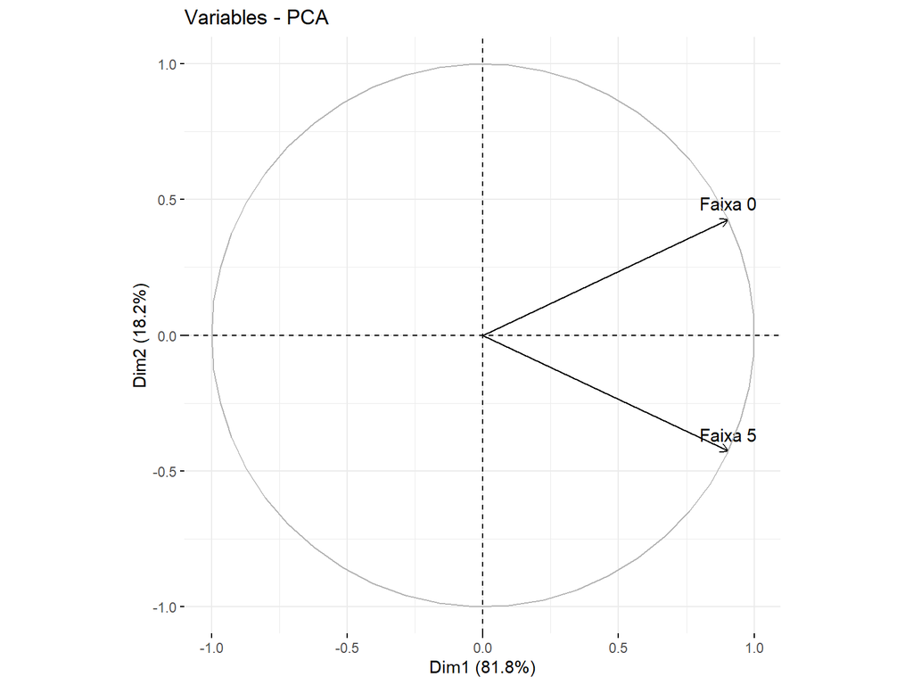

As diferenças de direção sugerem a existência de especifidades de variação não convergentes entre as faixas de renda. O gráfico, a seguir, mostra as diferenças de tendência na distribuição dos benefícios eventuais.

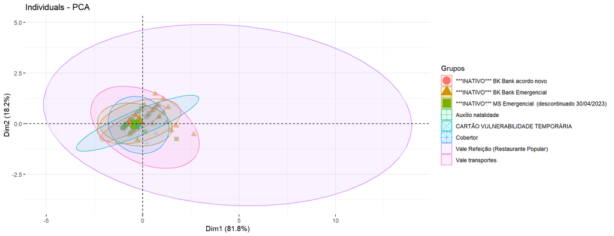

A PCA mostrou que faixa de renda é uma variável importante a ser considerada quando se discute benefícios eventuais.

# 8. Comparando benefícios eventuais entre territórios[^1], segundo a faixa de renda

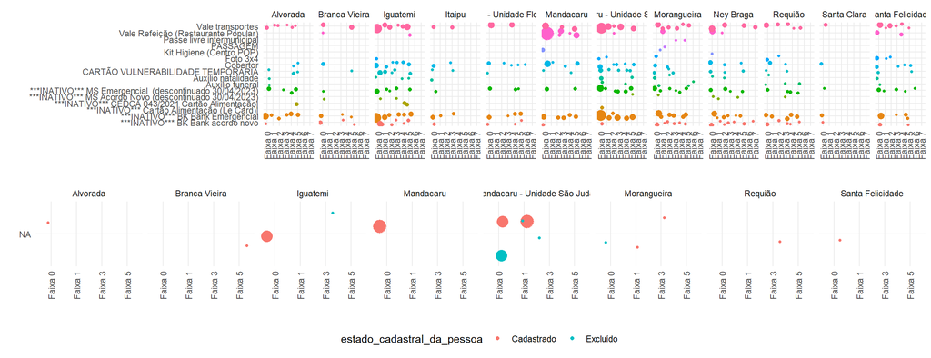

Os gráficos permitem inferir que, 1) há uma concentração de benefícios eventuais na faixa 0 nos territórios Iguatemi, Mandacaru e Mandacaru São Judas Tadeu; 2) dados do cadastro único mostram que a faixa 0 está concentrada nos territórios Iguatemi, Mandacaru e Mandacaru São Judas Tadeu.

# 9. Territórios de vida, segundo Idade, Sexo e Cor ou Raça

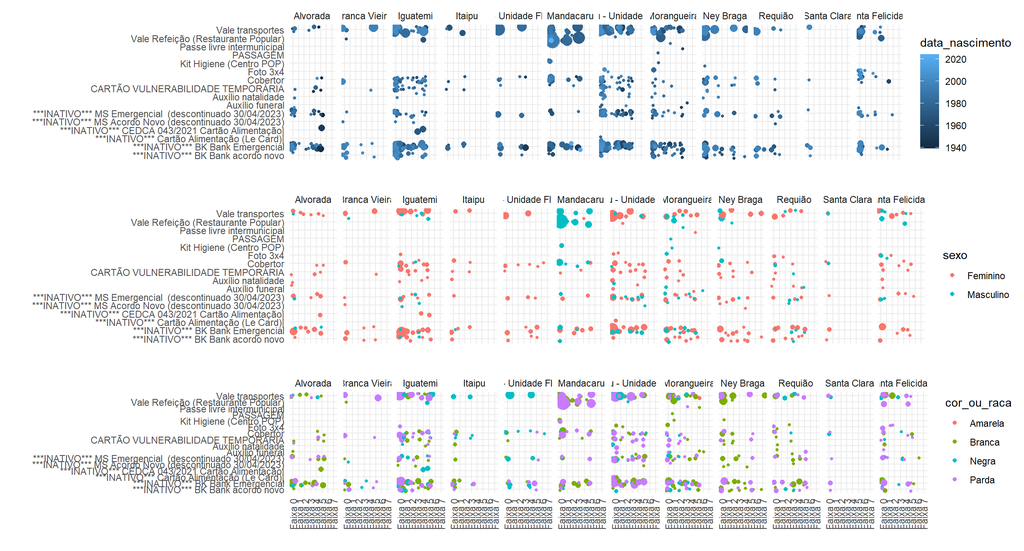

# 10. Concluindo

- A proposta do seminário foi discutir territórios relacionais em Maringá/PR, a partir de dados do CadÚnico.
- O objetivo consisttiu em discutir metodologias para mapear padrões territorializados de reprodução de situações de desproteção social, a partir da identificação de convergências entre condições de vida e laços sociais nos dados do cadastro único
- A noção território relacional é importante instrumento para delimitar sobreposições entre tipologias residenciais e trajetórias sociais que convergem para reprodução de situações de desproteção social
- AFC e PCA são algumas técnicas estatísticas que permitem o mapeamento de padrões de territórios relacionais combinando estatística e etnografia
- IA é outra ferramenta que pode ser utilizada como apoio e suporte
- O exercício realizado com os dados do CadÚnico e dos benefícios eventuais de Maringá/PR permitiu identificar a densidade de faixa 0 nas áreas de Iguatemi, Mandacaru e Mandacaru São Judas Tadeu, onde também concentram-se benefícios eventuais, considerando idade, raça e sexo
[^1]: Território aqui refere-se à noção nativa adotada pela equipe de Maringá no conjunto de dados.